# R Notebook

#Start with simple linear regression. Regress price on carat and check the regression diagnostics.

lets find model with the above explanatory variable

```r
model1 <- lm(price ~ carat, data = diamonds_new2)
model1
```

```
Call:
lm(formula = price ~ carat, data = diamonds_new2)

Coefficients:
(Intercept)        carat
      -2256         7756
```

```
`arrange_()` was deprecated in dplyr 0.7.0.
Please use `arrange()` instead.
See vignette('programming') for more help
```

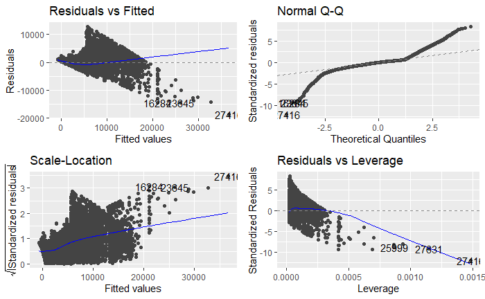

```r
autoplot(model1)
```

```r
summary(model1)
```

```
Call:
lm(formula = price ~ carat, data = diamonds_new2)

Residuals:
     Min       1Q   Median       3Q      Max
-18585.3   -804.8    -18.9    537.4  12731.7

Coefficients:
            Estimate Std. Error t value Pr(>|t|)
(Intercept) -2256.36      13.06  -172.8   <2e-16 ***
carat        7756.43      14.07   551.4   <2e-16 ***
---
Signif. codes:  0 ‘***’ 0.001 ‘**’ 0.01 ‘*’ 0.05 ‘.’ 0.1 ‘ ’ 1

Residual standard error: 1549 on 53938 degrees of freedom
Multiple R-squared:  0.8493,    Adjusted R-squared:  0.8493
F-statistic: 3.041e+05 on 1 and 53938 DF,  p-value: < 2.2e-16
```

How much explaining is the model doing?

85% of variation in price is explained by carat(x variable) For every 1 carat weight increase , the price will increase by 7756 dollars, however all other variables are constant

#Add another predictor of your choice. Check your assumptions, diagnostics, and interpret the model.

Predictor = cut

```r
diamonds_new2
```

| X1 | carat | cut | depth | table | price | clarity_IF | clarity_SI1 | clarity_SI2 | clarity_VS1 | clarity_VS2 | clarity_VVS1 | clarity_VVS2 | color_E | color_F | color_G | color_H | color_I | color_J |
| --- | --- | --- | --- | --- | --- | --- | --- | --- | --- | --- | --- | --- | --- | --- | --- | --- | --- | --- |
| 1 | 0.23 | 5 | 61.5 | 55.0 | 326 | 0 | 0 | 1 | 0 | 0 | 0 | 0 | 1 | 0 | 0 | 0 | 0 | 0 |
| 2 | 0.21 | 4 | 59.8 | 61.0 | 326 | 0 | 1 | 0 | 0 | 0 | 0 | 0 | 1 | 0 | 0 | 0 | 0 | 0 |
| 3 | 0.23 | 2 | 56.9 | 65.0 | 327 | 0 | 0 | 0 | 1 | 0 | 0 | 0 | 1 | 0 | 0 | 0 | 0 | 0 |
| 4 | 0.29 | 4 | 62.4 | 58.0 | 334 | 0 | 0 | 0 | 0 | 1 | 0 | 0 | 0 | 0 | 0 | 0 | 1 | 0 |
| 5 | 0.31 | 2 | 63.3 | 58.0 | 335 | 0 | 0 | 1 | 0 | 0 | 0 | 0 | 0 | 0 | 0 | 0 | 0 | 1 |
| 6 | 0.24 | 3 | 62.8 | 57.0 | 336 | 0 | 0 | 0 | 0 | 0 | 0 | 1 | 0 | 0 | 0 | 0 | 0 | 1 |
| 7 | 0.24 | 3 | 62.3 | 57.0 | 336 | 0 | 0 | 0 | 0 | 0 | 1 | 0 | 0 | 0 | 0 | 0 | 1 | 0 |
| 8 | 0.26 | 3 | 61.9 | 55.0 | 337 | 0 | 1 | 0 | 0 | 0 | 0 | 0 | 0 | 0 | 0 | 1 | 0 | 0 |
| 9 | 0.22 | 1 | 65.1 | 61.0 | 337 | 0 | 0 | 0 | 0 | 1 | 0 | 0 | 1 | 0 | 0 | 0 | 0 | 0 |
| 10 | 0.23 | 3 | 59.4 | 61.0 | 338 | 0 | 0 | 0 | 1 | 0 | 0 | 0 | 0 | 0 | 0 | 1 | 0 | 0 |

[output cut: 990 more lines]

```r
model2 <- lm(price ~ carat + cut, data = diamonds_new2)
model2
```

```
Call:
lm(formula = price ~ carat + cut, data = diamonds_new2)

Coefficients:
(Intercept)        carat          cut
      -3329         7838          258
```

```r
summary(model2)
```

```
Call:
lm(formula = price ~ carat + cut, data = diamonds_new2)

Residuals:
     Min       1Q   Median       3Q      Max
-18181.6   -780.4    -39.6    508.4  12945.1

Coefficients:
             Estimate Std. Error t value Pr(>|t|)
(Intercept) -3329.038     27.770 -119.88   <2e-16 ***
carat        7838.450     13.953  561.76   <2e-16 ***
cut           257.992      5.923   43.55   <2e-16 ***
---
Signif. codes:  0 ‘***’ 0.001 ‘**’ 0.01 ‘*’ 0.05 ‘.’ 0.1 ‘ ’ 1

Residual standard error: 1522 on 53937 degrees of freedom
Multiple R-squared:  0.8544,    Adjusted R-squared:  0.8544
F-statistic: 1.583e+05 on 2 and 53937 DF,  p-value: < 2.2e-16
```

How much explaining is the model doing?

```r
names(diamonds_new2)
```

```
 [1] "X1"           "carat"        "cut"          "depth"        "table"        "price"
 [7] "clarity_IF"   "clarity_SI1"  "clarity_SI2"  "clarity_VS1"  "clarity_VS2"  "clarity_VVS1"
[13] "clarity_VVS2" "color_E"      "color_F"      "color_G"      "color_H"      "color_I"
[19] "color_J"
```

```r
model3 <- lm(price ~ carat + clarity_IF + clarity_SI1 + clarity_SI2 + clarity_VS1 + clarity_VS2 + clarity_VVS1 +  clarity_VVS2, data = diamonds_new2)

model3
```

```
Call:
lm(formula = price ~ carat + clarity_IF + clarity_SI1 + clarity_SI2 +
    clarity_VS1 + clarity_VS2 + clarity_VVS1 + clarity_VVS2,
    data = diamonds_new2)

Coefficients:
 (Intercept)         carat    clarity_IF   clarity_SI1   clarity_SI2   clarity_VS1   clarity_VS2
       -6912          8440          5513          3729          2879          4614          4389
clarity_VVS1  clarity_VVS2
        5187          5163
```

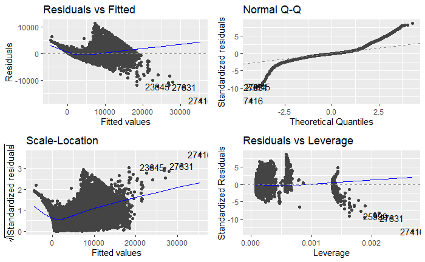

```r
autoplot(model3)
```

```r
summary(model3)
```

```
Call:
lm(formula = price ~ carat + clarity_IF + clarity_SI1 + clarity_SI2 +
    clarity_VS1 + clarity_VS2 + clarity_VVS1 + clarity_VVS2,
    data = diamonds_new2)

Residuals:
     Min       1Q   Median       3Q      Max
-17355.1   -639.9   -110.6    480.4  11162.8

Coefficients:
             Estimate Std. Error t value Pr(>|t|)
(Intercept)  -6911.57      50.22 -137.61   <2e-16 ***
carat         8440.06      12.65  667.13   <2e-16 ***
clarity_IF    5513.14      57.37   96.11   <2e-16 ***
clarity_SI1   3729.45      49.16   75.86   <2e-16 ***
clarity_SI2   2879.18      49.47   58.20   <2e-16 ***
clarity_VS1   4613.76      50.13   92.03   <2e-16 ***
clarity_VS2   4388.90      49.38   88.88   <2e-16 ***
clarity_VVS1  5186.62      53.05   97.77   <2e-16 ***
clarity_VVS2  5163.32      51.62  100.02   <2e-16 ***
---
Signif. codes:  0 ‘***’ 0.001 ‘**’ 0.01 ‘*’ 0.05 ‘.’ 0.1 ‘ ’ 1

Residual standard error: 1294 on 53931 degrees of freedom
Multiple R-squared:  0.8949,    Adjusted R-squared:  0.8948
F-statistic: 5.737e+04 on 8 and 53931 DF,  p-value: < 2.2e-16
```

```r
model4 <- lm(price ~ carat + clarity_IF + clarity_SI1 + clarity_SI2 + clarity_VS1 + clarity_VS2 + clarity_VVS1 +  clarity_VVS2+ color_E+ color_F + color_G + color_H + color_I + color_J, data = diamonds_new2)
```

```r
summary(model4)
```

[output not shown]